# EM MNIST

### Analysis of MNIST Data with EM Algorithm

In this project, we will work with the MNIST digits data of over 70 000 observations.

We implement the EM algorithm on this data for each class of digits (0,1,2,...,9) with different number of mixture models, M being assumed, where we will let M = 1; 3; 5.

For the 3 scenarios, where M = 1,3,5, we will try learn a generative model for each digit class. Then, we will classify the test set data using Bayes’ rule with your estimated class mixture models and report the results for M=1,3,5.

```python
import numpy as np
from numpy import random
import math
import sklearn
import statistics as stat
from scipy.linalg import sqrtm
import scipy
import warnings
warnings.filterwarnings('ignore')
import random
import matplotlib.pyplot as plt
from sklearn.model_selection import train_test_split
import copy
```

```python
"""
Import Data
"""
mnist = np.float64(np.load('MNIST.npy'))
labels = np.float32(np.load('MNIST_labels.npy'))
```

Recall that each observation has 28 x 28 variables, with each 1x1 variable being a pixel.

We will transform the dataset into one with binary response variables, where the variable value = 1 if there is any color, = 0 otherwise.

```python
mnist_data = np.zeros(shape = (len(mnist),784))
for i in range(70000):
    for j in range(784):
        if mnist[i,j] != 0:
            mnist_data[i,j] = 1
        else:
            mnist_data[i,j] = mnist[i,j]


##SPLIT DATA into TRAINING and TEST SET
#Test = 14000 (20%)
random.seed(1)
train_x, test_x, train_y, test_y = train_test_split(mnist_data,
                                    labels, train_size=0.8)
```

In the next cell, for ease, we will define an EM class with 3 functions. The first is to initialize the class, the second is to start the full algorithm running, and the 3rd to predict the results of the log-likelihood for the test set. We also define the function to display the images.

```python
"""
Function to visualize the observation as images
#Input: X is data to be visualized
"""
def diplay_images(rows,cols,X):
    plt.figure(figsize=(cols*2, rows*2))
    for i in range(rows*cols):
        plt.subplot(rows,cols, i+1)
        plt.imshow(X[i].reshape((28,28)), cmap="gray")
        plt.axis("off")
    plt.axis("off")
    plt.show()
```

Next, we shall code the full algorithm for Expectation-Maximization process.

```python
"""
Define Class for EM
"""

class EM:
    """
    Create a new object for every digit c, c = 0, ... 9,
    and every M =1,3,5
    """
    def __init__(self, c, M):
        self.c=c; self.M=M; self.components = 784


    """
    Define full alogrithm. Running this function will start
    the EM algorithm.
    """
    def full_algorithm(self, threshold):
        #Find data that relates to label c
        #Subset this dataset
        idx_k = np.where(train_y == self.c)[0]
        self.train_x_k = train_x[idx_k,:]
        self.n = self.train_x_k.shape[0]

        """
        Next, create empty vectors to hold various values
        for the iterations
        """
        #W (n x M matrix, each is w_im)
        self.W = np.zeros((self.n,self.M))
        #bernoulli parameter p_jm (components x M matrix)
        self.P = np.zeros((self.components, self.M))
        #Pi_m (M vector)
        self.pi = np.zeros((self.M))
        #Matrix of log-likelihood (pi_m * f_m)
        self.loglik = np.zeros((self.n, self.M))

        """
        Initiate initial values
        """
        self.overall_loglik = 0
        #Set initial difference to be big
        self.difference = 1000000000000000

        #Initialize value of W
        for i in range(self.n):
            #randomly choose a component's weight = 1, for all i
            self.W[i, np.random.choice(range(M), 1)[0]] = 1

        #START ITERATION
        self.count = 0

        """
        Begin the iteration. Continue as long as the diff
        is more than the threshold given in function
        """
        while self.difference >= threshold:
            """
            Estimate pi based on values of new W
            Estimate p_jm based on new values of W
            """
            self.count = self.count + 1

            #restimate pi
            for m in range(self.M):
                self.pi[m] = (1 + sum(self.W[:,m])) / (self.n + 2)

            #reestimate p_jm
            for j in range(self.components):
                for m in range(self.M):
                    bottom = sum(self.W[:,m])+2
                    top = sum(self.W[:,m] * self.train_x_k[:,j]) + 1
                    self.P[j,m] = top/bottom

            """
            COMPUTE new W
            """
            #Log-likelihood of each i under each m
            #calculated with new estiamtes of p_jm and pi
            for m in range(self.M):
                for i in range(self.n):
                    a = np.log(self.pi[m])
                    b = sum(self.train_x_k[i,:]*np.log(self.P[:,m])+\
                            (1-self.train_x_k[i,:])*
                            (np.log(1-self.P[:,m])))
                    self.loglik[i,m] = a + b
            for i in range(self.n):
                #Find largest one - L
                L = max(self.loglik[i,:])
                for m in range(self.M):
                    top = np.exp(self.loglik[i,m] - L)
                    bottom = sum([np.exp(self.loglik[i,cat] - L)
                                  for cat in range(self.M)])
                    self.W[i,m] = top/bottom

            #KEEP the previous value before we erase it
            self.overall_loglik_2 = copy.deepcopy(self.overall_loglik)
            self.overall_loglik = sum(np.log(np.sum(np.exp(self.loglik),
                                                    axis=1)))

            #Find change in log-likelihood
            self.difference = self.overall_loglik - self.overall_loglik_2
            #If difference > threshold, loop will stop
            #Otherwise loop will continue

        #Report Statistics once loop ends
        print("M=",self.M, " K=", c, " #Times=",self.count,
             " Loglikelihood=", self.overall_loglik, " Diff=",
              self.difference)

        return

    """
    Find loglik for the test set for a given m
    and given k
    Out: predicted loglikelihood for test data, for each digit
    """
    def predicted_loglik(self, X_test):
        test_n = X_test.shape[0]
        self.test_results = np.zeros((test_n))
        for i in range(X_test.shape[0]):
            self.predict_loglik[i] = sum(np.exp([np.log(self.pi[m])
                   + sum(np.log(self.P[:,m])*X_test[i,:]+
                   (1 - X_test[i,:])*np.log(1-self.P[:,m]))
                   for m in range(self.M)]))
        return
```

```python
#Perform EM
results_list = {}
k_list = range(10)
M_list = [1,3,5]

#Perform EM algorithm for each M, for every single digit
#Set threshold = 0.01 to end the loop
for M in M_list:
    results_list[M] = {}
    for k in k_list:
        results_list[M][k] = EM(c=k, M=M)
        results_list[M][k].full_algorithm(threshold=0.01)
```

```
M= 1  K= 0  #Times= 2  Loglikelihood= -1143187.8607476463  Diff= 0.0
M= 1  K= 1  #Times= 2  Loglikelihood= -697498.2678857538  Diff= 0.0
M= 1  K= 2  #Times= 2  Loglikelihood= -1249311.3010912596  Diff= 0.0
M= 1  K= 3  #Times= 2  Loglikelihood= -1179974.3878514634  Diff= 0.0
M= 1  K= 4  #Times= 2  Loglikelihood= -1074039.8685723788  Diff= 0.0
M= 1  K= 5  #Times= 2  Loglikelihood= -1130032.347770161  Diff= 0.0
M= 1  K= 6  #Times= 2  Loglikelihood= -1044721.6284502763  Diff= 0.0
M= 1  K= 7  #Times= 2  Loglikelihood= -1030090.9438371765  Diff= 0.0
M= 1  K= 8  #Times= 2  Loglikelihood= -1085451.649067898  Diff= 0.0
M= 1  K= 9  #Times= 2  Loglikelihood= -976467.894445728  Diff= 0.0
M= 3  K= 0  #Times= 32  Loglikelihood= -947085.8351700087  Diff= 0.006955865537747741
M= 3  K= 1  #Times= 30  Loglikelihood= -470877.3657064684  Diff= 0.0075182735454291105
M= 3  K= 2  #Times= 47  Loglikelihood= -1105736.686791681  Diff= 0.007047916296869516
M= 3  K= 3  #Times= 108  Loglikelihood= -1038933.7830412599  Diff= 0.009732130798511207
M= 3  K= 4  #Times= 32  Loglikelihood= -926468.9519313695  Diff= 0.006950838724151254
M= 3  K= 5  #Times= 63  Loglikelihood= -946695.1551609852  Diff= 0.007377127651125193
M= 3  K= 6  #Times= 24  Loglikelihood= -852953.8660658576  Diff= 0.00843719718977809
M= 3  K= 7  #Times= 51  Loglikelihood= -862914.028002984  Diff= 0.0028464181814342737
M= 3  K= 8  #Times= 66  Loglikelihood= -942043.7477981148  Diff= 0.009125641663558781
M= 3  K= 9  #Times= 49  Loglikelihood= -807789.3578710869  Diff= 0.004243496689014137
M= 5  K= 0  #Times= 109  Loglikelihood= -884474.8218240804  Diff= 0.009811610914766788
M= 5  K= 1  #Times= 69  Loglikelihood= -423008.4780620279  Diff= 0.009493589401245117
M= 5  K= 2  #Times= 182  Loglikelihood= -1053640.677777072  Diff= 0.008388291113078594
M= 5  K= 3  #Times= 135  Loglikelihood= -979964.4073544657  Diff= 0.008774999645538628
M= 5  K= 4  #Times= 57  Loglikelihood= -874030.4305199635  Diff= 0.005493563017807901
M= 5  K= 5  #Times= 57  Loglikelihood= -889656.1535533215  Diff= 0.008308788179419935
M= 5  K= 6  #Times= 64  Loglikelihood= -790637.9095522508  Diff= 0.0059863305650651455
M= 5  K= 7  #Times= 72  Loglikelihood= -804743.4009127959  Diff= 0.0030595642747357488
M= 5  K= 8  #Times= 139  Loglikelihood= -896532.3146035871  Diff= 0.009580591460689902
M= 5  K= 9  #Times= 60  Loglikelihood= -749194.950047577  Diff= 0.009702009847387671
```

```
M =  1
K =  0
```

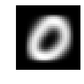

```
K =  1
```

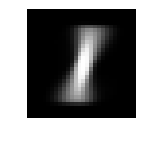

```
K =  2
```

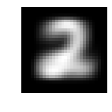

```
K =  3
```

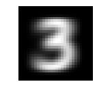

```
K =  4
```

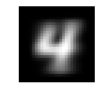

```
K =  5
```

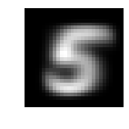

```
K =  6
```

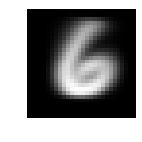

```
K =  7
```

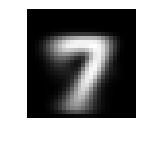

```
K =  8
```

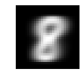

```
K =  9
```

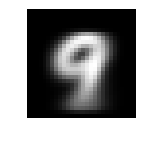

```
M =  3
K =  0
```

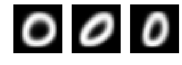

```
K =  1
```

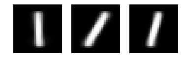

```
K =  2
```

[18 more figures not shown]

```python
"""
After performing the algorithm, display the mean of the generative model for each digit, and for different Ms,
as an image.

DISPLAY AS IMAGES
"""

#Each row is for a particular value of digit, under a particular M
#Each column is the probabilities p_jm for a particular model
for M in M_list:
    print("M = ", M)
    for k in k_list:
        print("K = ", k)
        diplay_images(1, M, results_list[M][k].P.T)
```

For each K, and under each M=1,3,5, the images portray the digit from that model rather clearly. When M=1, the image is slightly less clear than images from M=3 or 5.

For larger M, observe that the resolution of each image is slightly higher. In addition, each column captures / portrays the digit slightly differently. For example, each column / distribution model could portray the digits slanting/rotating in different directions, or the horizontal size of the loops (e.g. for 0, 9, 8). This implies that when M is large, the models are able to capture more variances in the probability vectors.

```python
"""
APPLY TRAINED MODEL TO TEST SET
"""
test_loglike_list = {}
n_test = test_x.shape[0]

#Here, we first calculate the log-likelihood of an observation under
# a particular digit model, for each value of M
test_class_list = {}
for M in M_list:
    test_class_list[M] = np.zeros((n_test))
    test_loglike_list[M] = np.zeros((n_test, 10))
    for k in k_list:
        results_list[M][k].predicted_loglik(test_x)
        test_loglike_list[M][:,k] = results_list[M][k].predict_loglik

    #Next, we predict a class to each test observation
    #based on which class has the highest log-likelihood
    test_class_list[M] = [np.argmax(test_loglike_list[M][i,:])
                          for i in range(n_test)]

error = np.zeros((3))

#Print the accuracy rate for each M
for position in range(3):
    error[position]=sum(test_class_list[M_list[position]]!=test_y)/n_test
    print("Accuracy Rate of M = ",
          M_list[position], " is ", 1 - error[position])
```

```
Accuracy Rate of M =  1  is  0.8306428571428571
Accuracy Rate of M =  3  is  0.8947142857142857
Accuracy Rate of M =  5  is  0.9091428571428571
```

Observe that the lowest accuracy rate is when M=1. When M=3, the jump improves significantly from 0.8306 to 0.8947. When M=5, the rate improves again to 0.909, but this change is small compared to before. Hence, M=3 may be a good balance between accuracy of prediction and the speed/complexity of calculations.